# HW04 Part 1: Complete Chapter 3

Taylor Simmonds

26 December 2018

## Chapter 3

- Change “your name” in the YAML header above to your name.

### Section 3.1

Load the tidyverse packages. I’ve entered the first code chunk for you. **You must enter all subsequent code chunks and run the code.**

```r
library("tidyverse")
```

If you get an error, then you did not install the `tidyverse` package like you were supposed to in the previous assignment. Go back to that assignment and complete that step. (This should not be the case, though.)

### Section 3.2: First steps

Enter your code chunks for Section 3.2 here.

Get in the habit of entering a brief description of what each chunk of code does. Enter this above the chunk, like I did in Section 3.1.

Loaded mpg data frame and found its dimensions. Created scatterplot comparing hwy/cyl and class/drv.

```r
ggplot2::mpg
```

| manufacturer | model | displ | year | cyl | trans | drv | cty | hwy | fl | class |
| --- | --- | --- | --- | --- | --- | --- | --- | --- | --- | --- |
| audi | a4 | 1.8 | 1999 | 4 | auto(l5) | f | 18 | 29 | p | compact |
| audi | a4 | 1.8 | 1999 | 4 | manual(m5) | f | 21 | 29 | p | compact |
| audi | a4 | 2.0 | 2008 | 4 | manual(m6) | f | 20 | 31 | p | compact |
| audi | a4 | 2.0 | 2008 | 4 | auto(av) | f | 21 | 30 | p | compact |
| audi | a4 | 2.8 | 1999 | 6 | auto(l5) | f | 16 | 26 | p | compact |
| audi | a4 | 2.8 | 1999 | 6 | manual(m5) | f | 18 | 26 | p | compact |
| audi | a4 | 3.1 | 2008 | 6 | auto(av) | f | 18 | 27 | p | compact |
| audi | a4 quattro | 1.8 | 1999 | 4 | manual(m5) | 4 | 18 | 26 | p | compact |
| audi | a4 quattro | 1.8 | 1999 | 4 | auto(l5) | 4 | 16 | 25 | p | compact |
| audi | a4 quattro | 2.0 | 2008 | 4 | manual(m6) | 4 | 20 | 28 | p | compact |

[output cut: 224 more lines]

```r
dim(mpg)
```

```
[1] 234  11
```

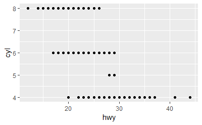

```r
?mpg
ggplot(data = mpg) +
  geom_point(mapping = aes(x = hwy, y =cyl))
```

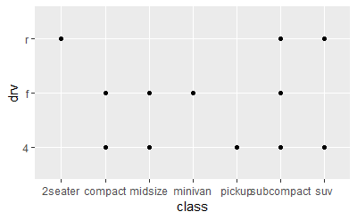

```r
ggplot(data = mpg) +
  geom_point(mapping = aes(x = class, y=drv))
```

#### Section 3.2 Questions

Answer the questions *completely.* Some answers will require you to write code in a code chunk and also to type text before or after the chunk. Other answers will require only code or only text.

**1:** Run ggplot(data = mpg). What do you see? A data frame containing variables in the mpg dataset.

**3:** What does the `drv` variable describe? Read the help for `?mpg` to find out. drv describes the style of driving for f = front, r=rear wheel drive and 4=4wd

**4:** Make a scatterplot of `hwy` vs `cyl`.

**5:** What happens if you make a scatterplot of `class` vs `drv`? Why is the plot not useful? The driving style of the car and the type of car show no significant data trends when graphed together, these factors alone do not help in comparing fuel economy across various cars.

### Section 3.3

Shows a scatterplot of displ and hwy

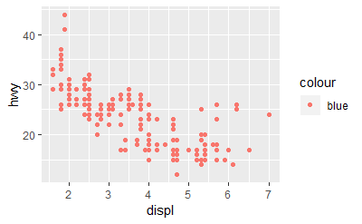

```r
?points
ggplot(data = mpg) +
  geom_point(mapping = aes(x=displ, y=hwy, color = "blue"))
```

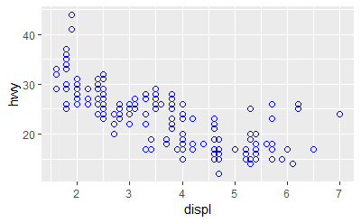

```r
ggplot(data = mpg) +
  geom_point(mapping = aes(x=displ, y=hwy), color="blue", pch=1, cex=2)
```

Display a scatterplot for drv/class

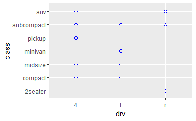

```r
ggplot(data = mpg) +
  geom_point(mapping = aes(x=drv, y=class), color="blue", pch=1, cex=2)
```

Applying two color aesthetics to the same variable

```r
ggplot2::data = mpg +
  geom_point(mapping = aes(x=displ, y=hwy), color="blue", color="red", pch=1, cex=2)
```

[output not shown]

Applying an aesthetic to something other than a variable name.

```r
ggplot2::data = mpg +
  geom_point(mapping =aes(colour = displ < 5))
```

[output not shown]

### Section 3.3: Aesthetic mappings

#### Section 3.3 questions

**1:** What’s gone wrong with this code? Why are the points not blue? It needs to be written (mapping = aes(x=displ, y=hwy), color=“blue”).

**2:** Which variables in `mpg` are categorical? Which variables are continuous? (*Hint:* type `?mpg` to read the documentation for the dataset). How can you see this information when you run mpg? Model name, type of transmission, drv, fl, and class. When mpg? is ran a help window shows in the bottom right of the screen.

**4:** What happens if you map the same variable to multiple aesthetics?

**5:** What does the stroke aesthetic do? What shapes does it work with? (*Hint:* use `?geom_point`) The stroke aesthetic allows for syombols to have a color and a fill, it works for shapes 21-24.

### Section 3.5: Facets

Facet plot for mpg

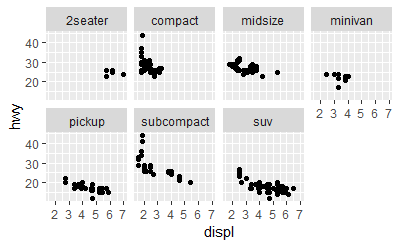

```r
ggplot(data = mpg) +
  geom_point(mapping = aes(x = displ, y = hwy)) +
  facet_wrap(~ class, nrow = 2)
```

Facet plot for drv and class.

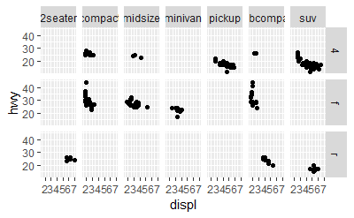

```r
ggplot(data = mpg) +
  geom_point(mapping = aes(x = displ, y = hwy)) +
  facet_grid(drv~ class)
```

Facet plotted with “.”

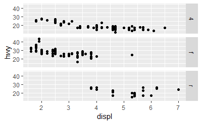

```r
ggplot(data = mpg) +
  geom_point(mapping = aes(x = displ, y = hwy)) +
  facet_grid(drv ~ .)
```

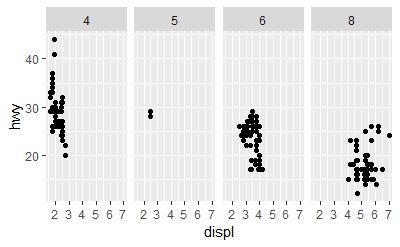

```r
ggplot(data = mpg) +
  geom_point(mapping = aes(x = displ, y = hwy)) +
  facet_grid(. ~ cyl)
```

Plot for displ and hwy with a facet for class

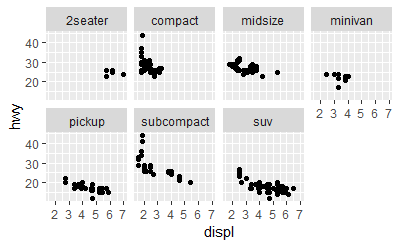

```r
ggplot(data = mpg) +
  geom_point(mapping = aes(x = displ, y = hwy)) +
  facet_wrap(~ class, nrow = 2)
```

```r
?facet_grid
```

#### Section 3.5 questions

**1:** What happens if you facet on a continuous variable? **Note:** Write a prediction, then make and run your code chunk.

This should split the plot into various subplots that each display a specific portion of the dataset.

**2:** What do the empty cells in plot with `facet_grid(drv ~ cyl)` mean? How do they relate to this plot? The empty cells show that those car styles do not come in rear wheel drive and that the 2 seater car does not come in 4 wheel or front wheel drive. This shows what style of driving is available for each car type.

**3:** What plots does the following code make? What does `.` do? “drv~.” creates a subplot that does not properly split the displ variable across the graph and “.~cyl” creates a subplot that shows the displ and cyl variable. The “.” tells the subplot that there should be no faceting on that specific variable.

**4:** Take the first faceted plot below. What are the advantages to using faceting instead of the colour aesthetic? What are the disadvantages? How might the balance change if you had a larger dataset? Facet would be a quick way to sort small amounts of data, but color would be easier and quicker to digest and understand larger datasets.

**5:** Read `?facet_wrap`. What does `nrow` do? What does `ncol` do? What other options control the layout of the individual panels? Why doesn’t `facet_grid()` have nrow and ncol argument? nrow and ncol set the number of rows and columns respectively. Labeller and switch control the layout of the individual panels. “facet_grid” has rows/cols because instead of setting the number of rows/cols it sets the name of them through labeller.

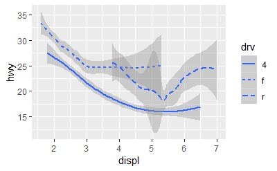

```r
ggplot(data = mpg) +
  geom_smooth(mapping = aes(x = displ, y = hwy, linetype = drv))
```

Graphing hwy and displ with color coded lines

```
Ignoring unknown aesthetics: show.legend
```

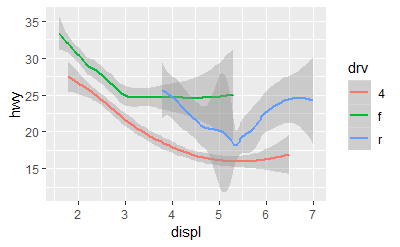

```r
ggplot(data = mpg) +
  geom_smooth(mapping = aes(x = displ, y = hwy, color = drv, show.legend = FALSE))
```

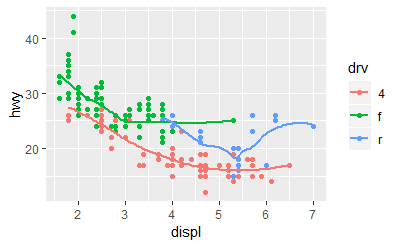

```r
ggplot(data = mpg, mapping = aes(x = displ, y = hwy, color = drv)) +
  geom_point() +
  geom_smooth(se = FALSE)
```

```r
??se
```

graph 1: hwy/displ with trend line

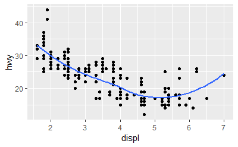

```r
ggplot(data = mpg, mapping = aes(x = displ, y = hwy)) +
  geom_point() +
  geom_smooth(se = FALSE)
```

#### Section 3.6.1 Questions

**1:** What geom would you use to draw a line chart? A boxplot? A histogram? An area chart? **Note:** You will have to make some types of these charts in Part 2 of this assignment. Line charts=linegoem, boxplot=boxplot geom, scatterplot= point geom.

**2:** Run this code in your head and predict what the output will look like. Then, run the code in R and check your predictions.

**3:** What does `show.legend = FALSE` do? What happens if you remove it? **Note:** Skip the “Why do you think I used it earlier in the chapter?” question. “show.legend = FALSE” removes the legend from the graph, but by default it is included if any aesthetics are mapped.

**4:** What does the `se` argument to `geom_smooth()` do? “se” displays confidence intervals around the smooth line graph.

**5:** Will these two graphs look different? Why/why not? The graphs should look the same because it is calling in the same data, it is just coded in teo different ways.

1: upper left.

2: upper right.

3: middle left.

4: middle right.

5: lower left.

6: lower right. *Hint:* Read the help file for `geom_point`. Use `shape = 21`, `stroke = 2`, and `size = 3`.

### Section 3.7: Statistical transformations.

**Skip this section.** We may return to it later.

### Section 3.8 Position adjustments

hwy/cty graph wiht jitters

```r
ggplot(data = mpg, mapping = aes(x = cty, y = hwy), position = jitter) +
  geom_point()
```

[output not shown]

```r
?position_jitter
```

Comparing jitter and count

```r
ggplot(data = mpg, mapping = aes(x = cty, y = hwy), position = jitter) +
  geom_point()
```

[output not shown]

```r
ggplot(data = mpg, mapping = aes(x = cty, y = hwy), position = count) +
  geom_point()
```

[output not shown]

mpg boxplot demonstration

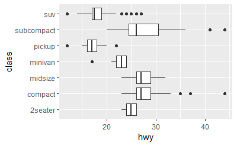

```r
ggplot(data = mpg, mapping = aes(x = class, y = hwy)) +
  geom_boxplot() +
  coord_flip()
```

#### Section 3.8 Questions

**1:** What is the problem with this plot? How could you improve it. *Hint:* Remember the size of the `mpg` data set from earlier in this exercise. Does the number of points seem correct? **Note:** Write the code to improve it. The data points are overlapping and making it hard to read the data and showing less data points than what is in the origianl data set.

**2:** What parameters to `geom_jitter()` control the amount of jittering? Width and height can be added to control the amount of jittering.

**4:** What is the default position adjustement for `geom_boxplot()`? Create a visualization of the `mpg` dataset that demonstrates it. Cartesian coordinate systmen where the x and y act independently to determine the location of each point.

### Section 3.9: Coordinate systems

**Note:** Read about and do only the code chunk associated with `coord_flip()`. `coord_flip()` is a great layer to use when you have categorical data with longish names as it makes the text easier to read.

### Section 3.10: The layered grammar of graphics

Just read this section as a contextual review of everything you just learned.